# Role User Guide

Radiant Logic

# Introduction

This document describes the principles of RadiantOne Identity Analytics Role Mining feature.

A Role Mining mission is the combination of a proven methodology and a powerful tool to create quality role modeling. This document focuses on the tool itself and not the methodology.

The role mining feature provides interfaces dedicated to the identification and analysis of roles.

Identities that are part of a given organization require specific rights to a given set of applications to perform daily tasks. These set of permission are different depending on several factors like the type of job, whether or not the identity is external to the organization and so on.

Identifying these set of permissions for a particular role is very useful when the time comes to audit existing rights. If we can clearly identify a set of permissions required for a particular task; we could for example, identify which identities have permissions that are not required.

This role mining feature provides the tools required to analyse the permissions by organization using review campaigns. This feature is now part of IAP2.0 and upper, and is activated by the license key. Note that before launching an execution plan, you need to set the variable “isRoleMiningActive” to “true” in the technical configuration of the project. This way, all the required metadata will be computed.

# Role mining pre-requisites

Please set the project variable “isRoleMiningActive” to “true” prior to the data ingestion so that the required metadata for your role mining campaigns will be pre-computed.

# Role mining campaign

The role mining feature is designed to be used together with the campaign manager. A role mining campaign is created and configured using the campaign manager. The campaign is used to configure different aspects of the role mining analysis like defining the scope of the analysis.

## Creating the campaign

From the main screen of the campaign manager, we can start a new campaign:

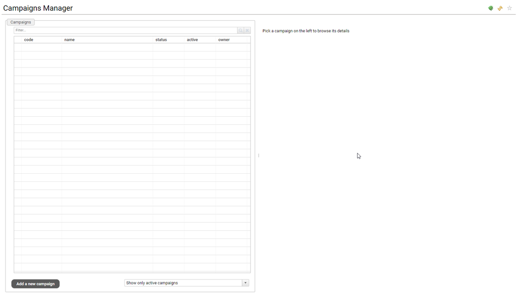

If the role mining feature has been activated in the license, we should now see an option to start a new role mining campaign.

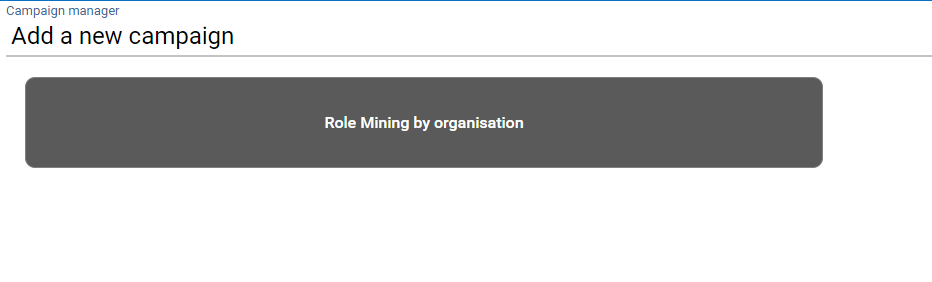

Selecting the role mining campaign will lead us to the campaign definition where we can select the scope of the analysis: organizations and permissions that will be part of the campaign as well as other information like campaign duration, campaign owner, etc.

A wizard for creating the scope will appear, with the first step being the information related to your role mining campaign, such as the role mining title and description, the role mining campaign owner, the campaign duration, priority level and so on.

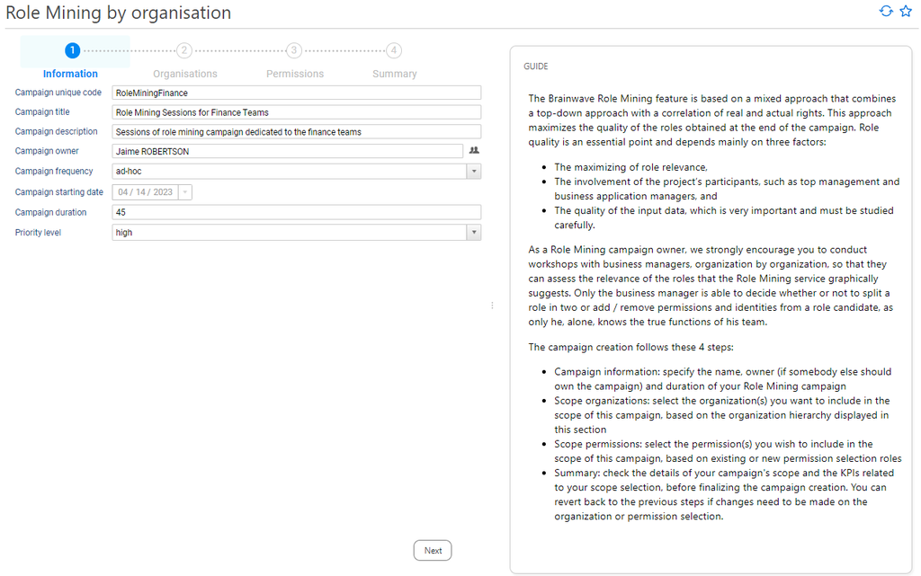

Once completed, you can reach the step 2 which consist of selecting the related departments.

### Organization Selection

In the Role Mining feature, the analysis is split by organization (or departments) because it is the key element on which it is based. One of the main advantages of this approach is that workshops can be conducted with the organization manager who knows his team and activities well.

The Organization Selection page looks like this:

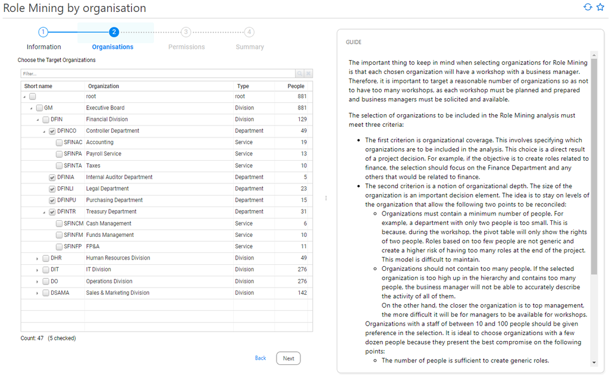

The table displays the list of organizations with the number of people in each organization. The headcount not only includes the people directly attached to the organization but also the people in sub-organizations. If the root organization is analyzed, the headcount will be that of the entire company.

The number of employees is an important parameter to watch when choosing organizations. The right balance must be found between organizations with a very small workforce and those with a larger workforce, as smaller organizations are of little interest when defining roles. In this case, the problem becomes that of the manager attending the workshop. If he or she is responsible for 1,000 people or more, he will not have sufficient detail on the business activity of each one. The Role Mining session will subsequently result in providing only approximate roles or those that are far from the operational reality.

Once the organizations have been chosen, it is possible to move on to the Permission Selection step.

### Permission Selection

To select permissions, a rule must be created by clicking on the three small dots to the right of the “Permission Criteria” field.

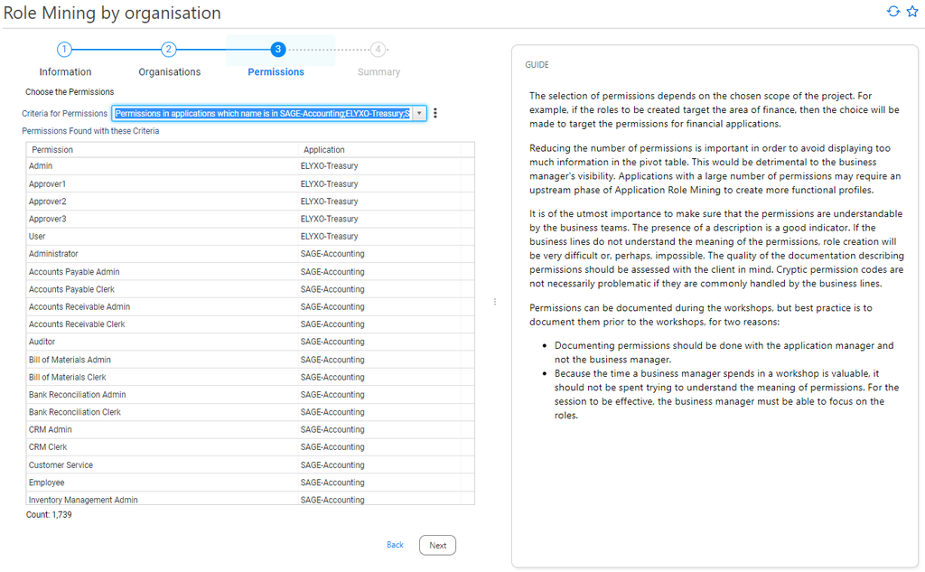

When “Create a Rule” is clicked on, a dialog box will appear:

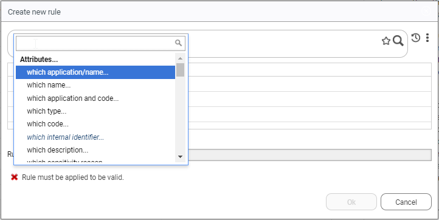

The first field allows for the criteria selection for the permissions to be included in the role mining analysis. These criteria are either attributes of the permissions (“Attributes”) or links to the rest of the data cube (“Relationships”). For example, if the decision is to include all the permissions in the Elyxo application, the link “in applications” can be added, after which the criteria “whose name is” can be followed by the name Elyxo.

Once the rule is written, clicking on the magnifying glass icon will display the result. A sentence is proposed as a rule title below the result list. This can be changed if a more concise name is desired. Clicking on “OK” closes the rule creation box. The rule is then selected in the Permissions page.

Several rules can be created, but only one can be selected at a time.

When the permissions brought back by the rule match the desired scope, click on “Next.”

### Scope Summary

The last page of the Scope wizard is the summary.

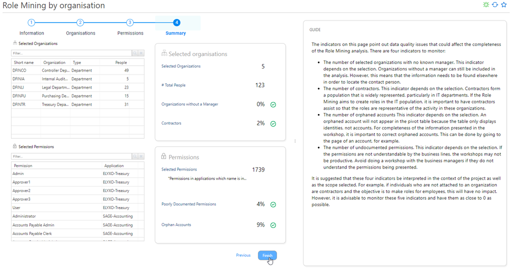

In addition to reminding the rules of organization and permission, the four KPIs presented allow to validate the data quality prior to launching the analysis.  
The KPIs are calculated on the scope only and not on the totality of the data of the role mining cube.

The KPIs available are:

- the number of organizations without a manager, and
- The number of contractors,
- the number of poorly or undocumented permissions,
- the number of orphaned accounts (accounts without an owner).

The counters and KPIs on this page do not guarantee the quality of the data. If uploaded files contain incomplete or obsolete information, it will not be detected and indicated on this form.

However, once the verification of the data content has been done, these KPIs make it possible to verify that the role mining analysis will present complete data, as they have a direct impact on the quality of the analysis. For example, poorly documented permissions will result in time lost in the workshop trying to figure out what business activity is behind the permission. Without fully understanding the permissions, relevant roles cannot be created. Another example to consider is identities that are not attached to an organization. These people will not be included in the analysis which is based on organizations. If a person is not identified as being part of an organization, he or she will not be considered in the analysis.

For each KPI, a percentage is displayed. This is the number of items (for example, the number of orphaned accounts) compared to the total number (the total number of accounts). An icon associated with each KPI allows the user to consider whether or not the percentage seems to be within reasonable limits. There are systematically two thresholds:

- a low threshold that triggers a warning (with an associated icon), and
- a high threshold that triggers an error (with an associated icon).

These thresholds are set by the Role Mining feature and cannot be modified. The following table gives the thresholds for the four KPIs:

| **KPI** | **Warning Threshold** | **Critical Threshold** | **Comment** |
| --- | --- | --- | --- |
| Contractors | 15% | 5% | See note to interpret thresholds |
| Organizations without a manager | 3% | 5% |  |
| Poorly documented permissions | 20% | 40% |  |
| Orphaned accounts | 20% | 30% |  |

Note: the first KPI (Contractors) works in a way that is the opposite of the three others. This KPI is used to verify that contractors have been loaded. If the percentage is 0, it means that no contractor files have been uploaded. Beyond 15%, there is a strong chance that all contractors are present in the database.

The KPIs are related to the selected scope. For example, for orphaned accounts, the percentage is calculated by comparing the number of accounts without an owner to the total number of accounts in the scope.

It is possible to see the details of all these KPIs by clicking on the icon located to the right of each KPI. A dialog box opens to show a list according to the type of KPI. The following example shows the KPI details for orphaned accounts.

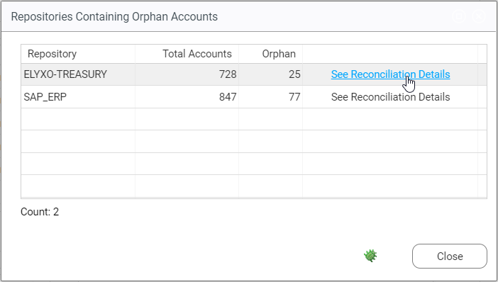

The details give the breakdown of the counters by repository (a repository being an application). The column entitled “See Reconciliation Details” takes the user directly to a page giving the statistics of orphaned accounts. From this page, and by navigating through the tabs, it is possible to change the account owners.

If all the KPIs are green, the Scope of Analysis can be validated by clicking on the “Finish” button.

Saving this information creates a new campaign template.

## Launching the campaign

The new campaign template will appear in the campaign manager, and from here it can be modifed by clicking on “Edit” if needed, or the template can be used to launch a new role mining campaign:

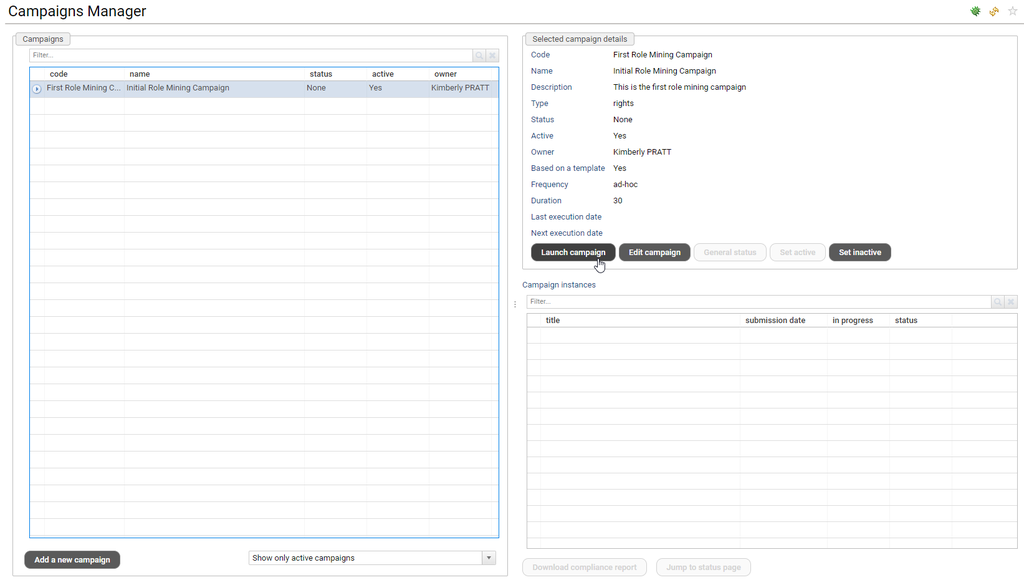

After the campaign has been properly launched, we will be able to see the campaign instance.

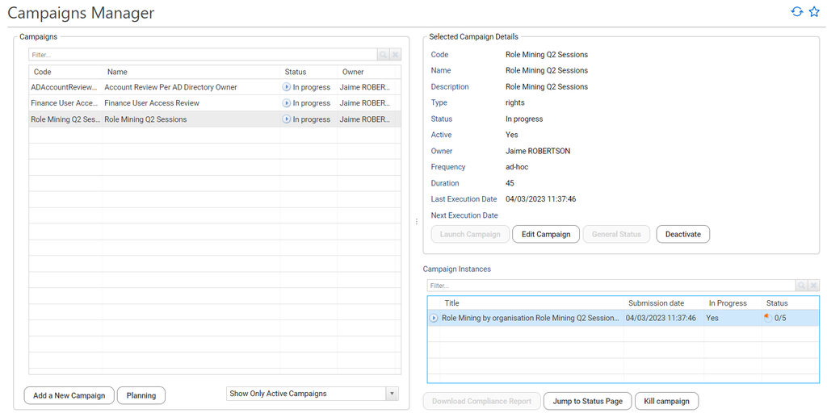

We can click “Jump to Status Page” of the campaign instance to see the current status and advancements of the campaign.

The campaign will consists on a list of tasks, and from here we can identify who is responsible for the task and we can also reassign the task to another person.

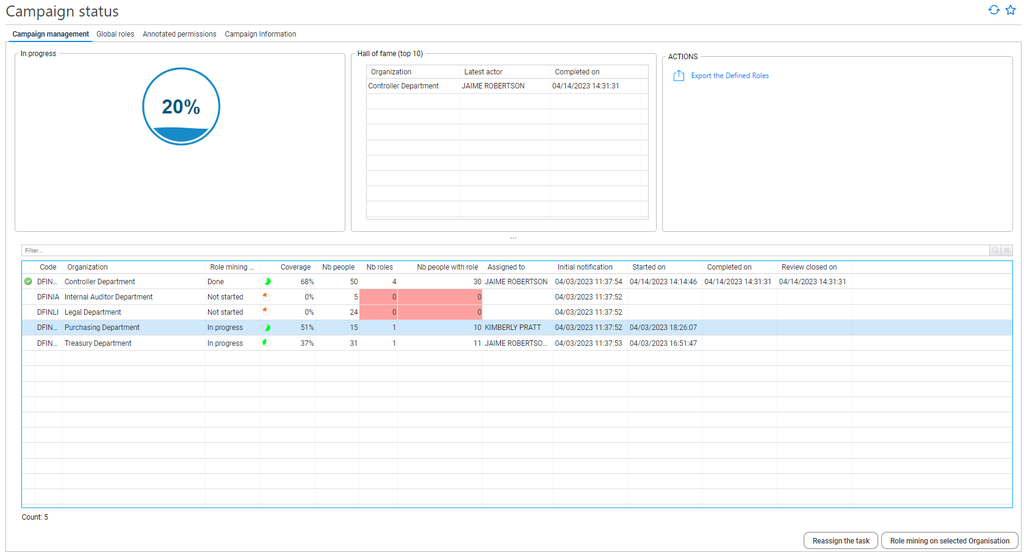

Take some time to explore the different tabs present in the campaign status page, here we will have access to:

- Global Roles

From this tab , we can define and manage the global roles. Please refer to the global roles section for more information.

- Annotated Permissions

All annotations that have been created will be seen here, and they can be updated.

- Campaign Information

A summary of the information related to the role mining campaign.

## Global Roles

A global role is a role that impacts a large set of people in the organization and includes a set of permissions that are given by default.

This kind of roles tend to introduce some noise when analyzing the permissions by organization since we will most likely find clusters of rights associated to these roles in all organizations that we select.

Defining the global roles will impact all organizations and can help reduce noise from the organization by organization approach that will be used to identify roles.

To create and manage these roles, go to the Global roles tab in the details page of any of the tasks that are part of a role mining campaign.

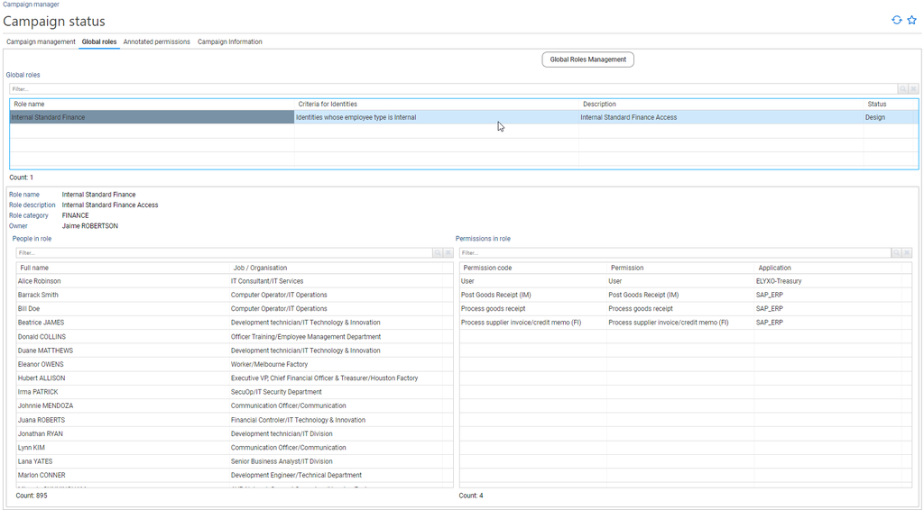

Use the tool available to manage those roles and to create new ones by clicking on the button “Global Roles Management”.

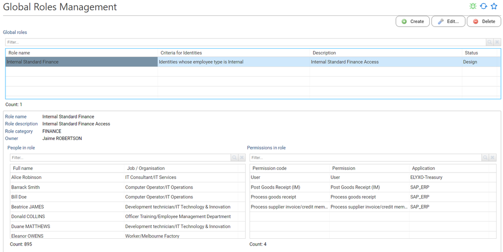

From there, you can create, edit or delete roles. When creating a new role, 4 steps need to be completed:

1. Identify the Identities

First you need to define the rule to list the identities that will be included in the global role. This rule should list a wide range of identities distributed among different departments, such as all contractors, or all internal employees.

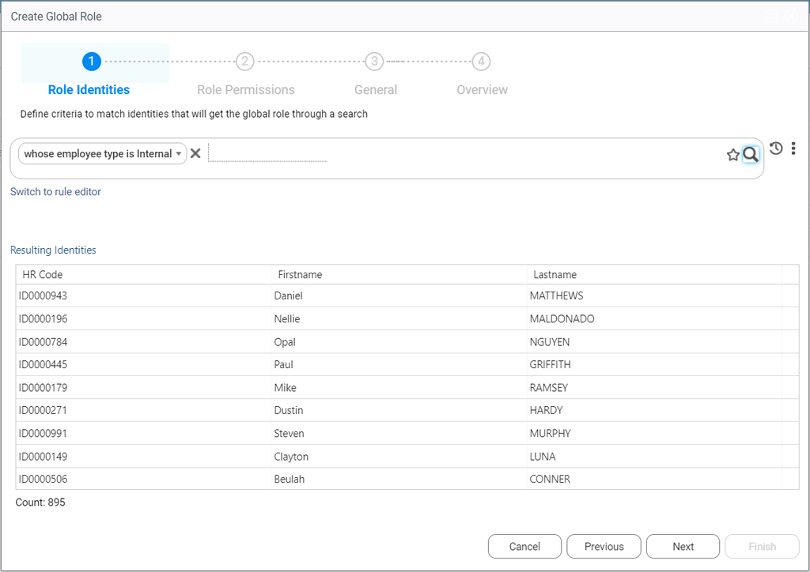

2. Identify the Permissions

Then you can select the approriate permissions using the provided analytics that help you to create consistant and accuracy global role. The table shows the permissions sorted per percentage of identities from the first step that can use the permission.

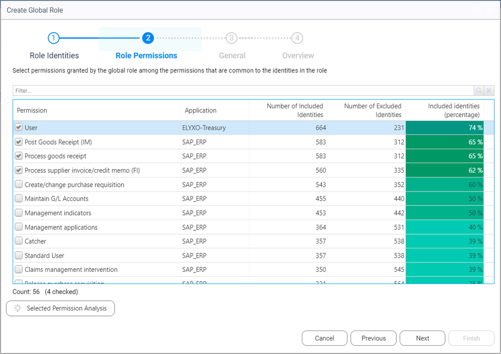

Additional analytics are available by clicking on the “Selected Permission Analysis” button to help you choose the right permissions for you global role:

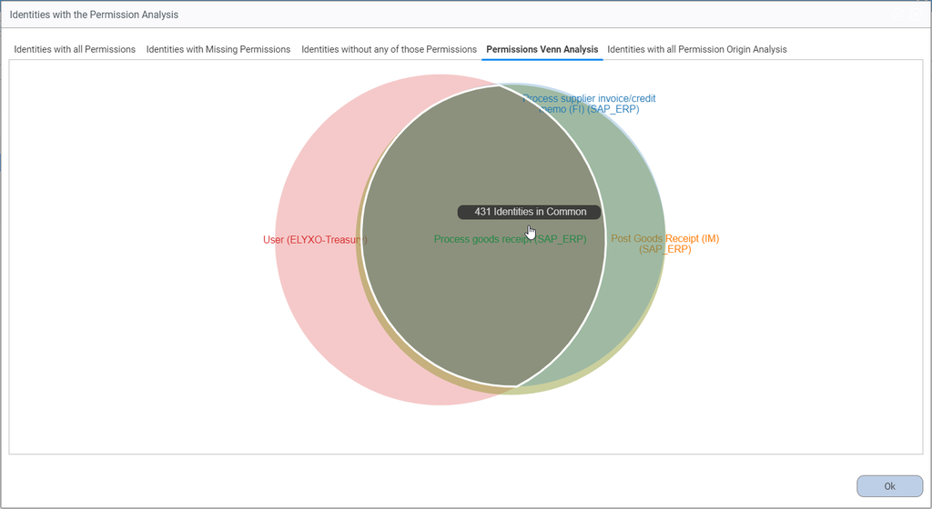

3. Provide Global Role Information

Then you can add general information about your new global role such as the role description, the role owner (to ease review for example), the role category, version and so on:

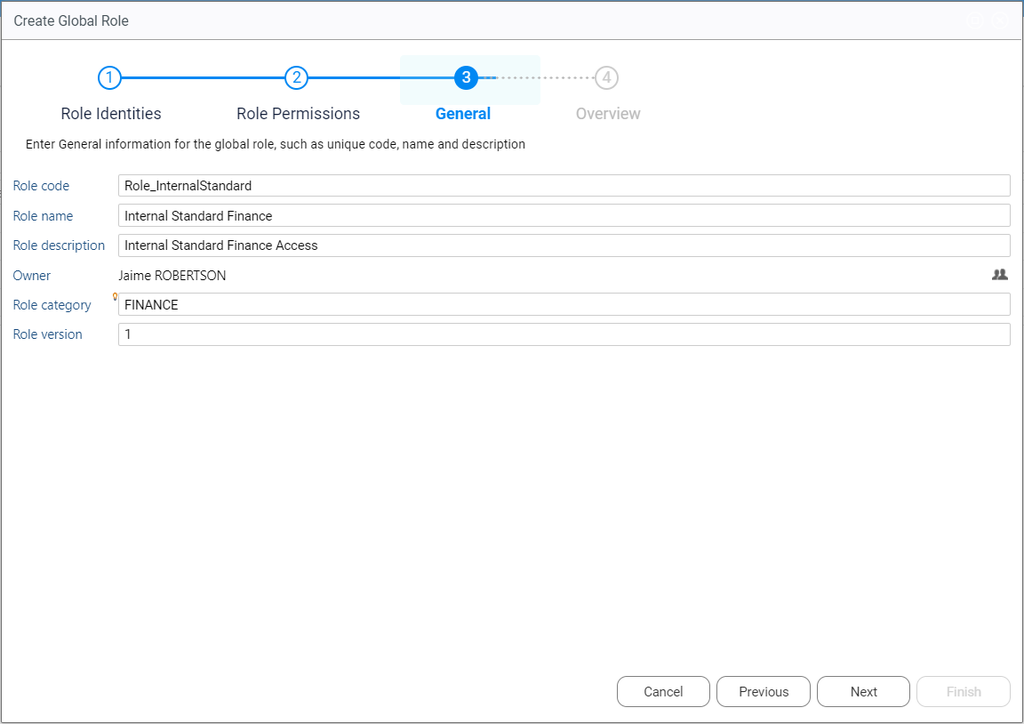

4. Review and Create the Global Role

The last step summarizes all the caracteritics of your global roles, including role information and role content (people and permissions). If all looks good, you can create it by clicking on “Finish”.

When all the global roles have been created, you can then manage your role mining campaign by reassigning tasks for example.

## Role Mining Tasks

When the task has been reassigned to an identity, the identity that is responsible for a role mining task will receive a notification email and will find the pending task in the task list.

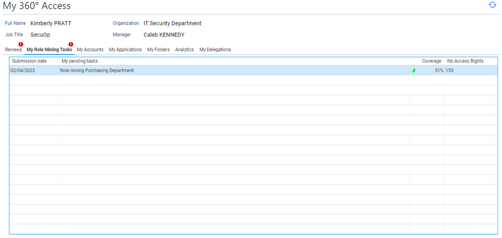

From there, the user will be able to take the task, and access to the main role mining interface.

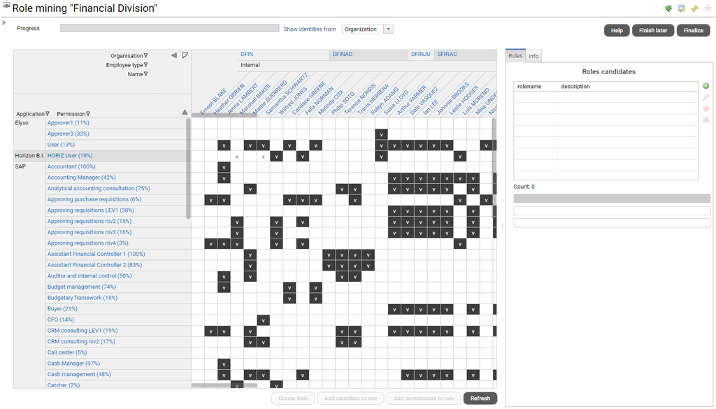

This interface is very rich and provide a lot of options and tools to help you visually identify roles.

### Advanced Filtering

Click on this button to access the advanced filtering options:

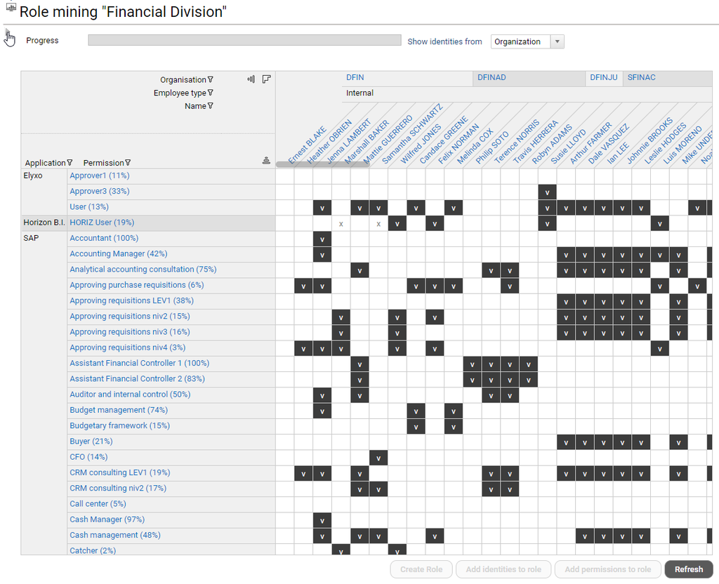

You will see all the available parameters that can help you reduce the analysis scope. From here, you can also access a list of reports to display details about the current state.

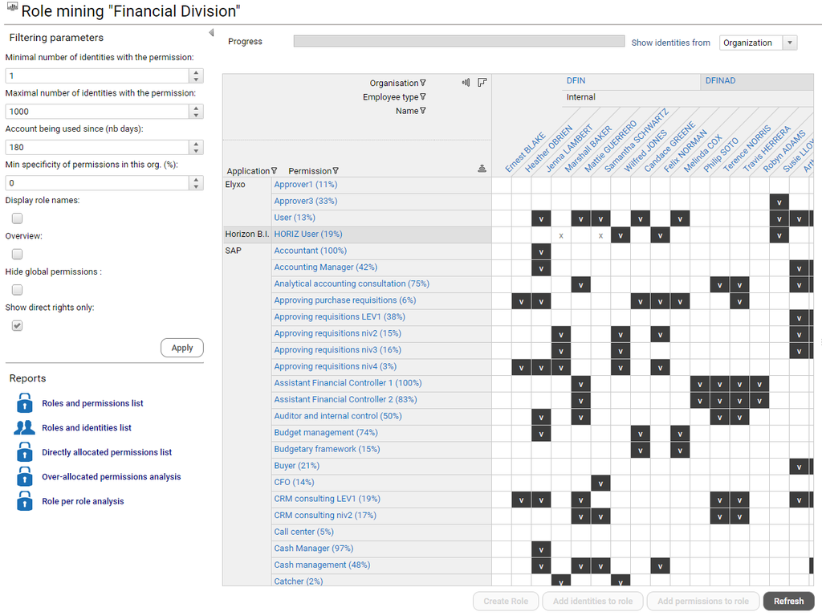

### Smart Grouping Button

This button will group permissions in blocks. It will be very useful to visually identify role candidates.

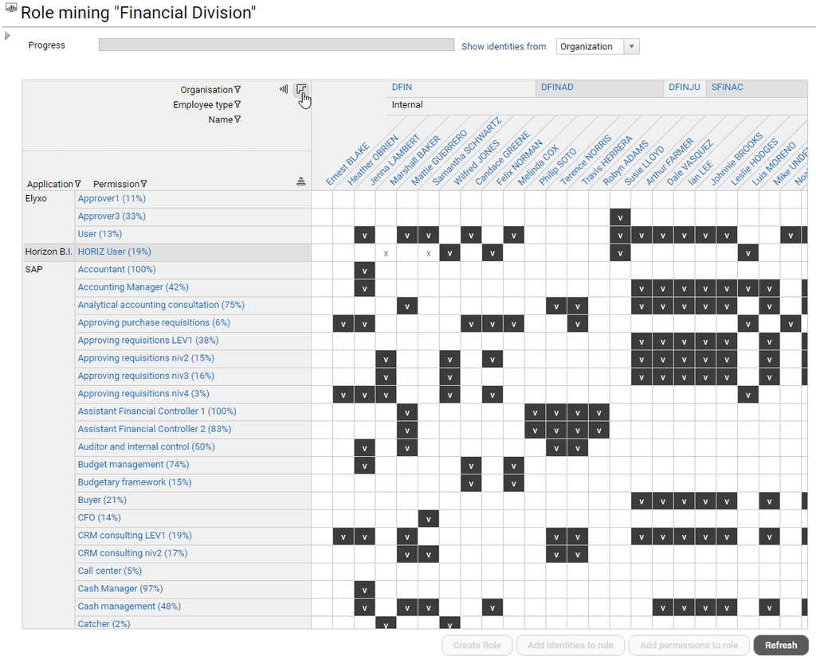

After the smart sorting, it will be a lot easier to identify roles:

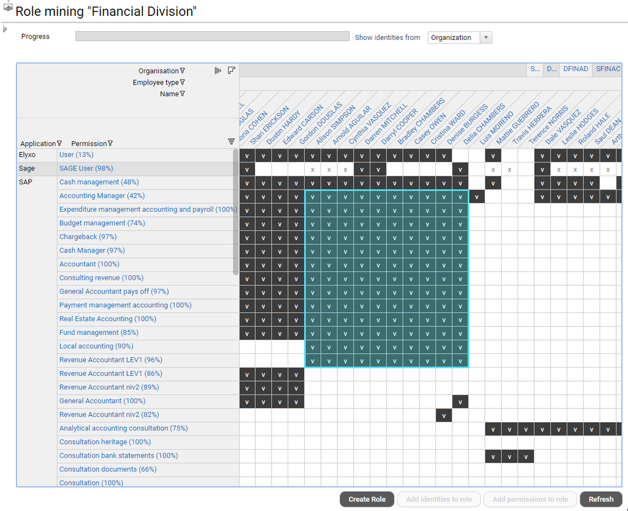

### Create Roles

Creating role candidates is as easy as selecting an area and clicking in “create role” will create a role that contains all identities and the permissions that are part of the area that is highlighted:

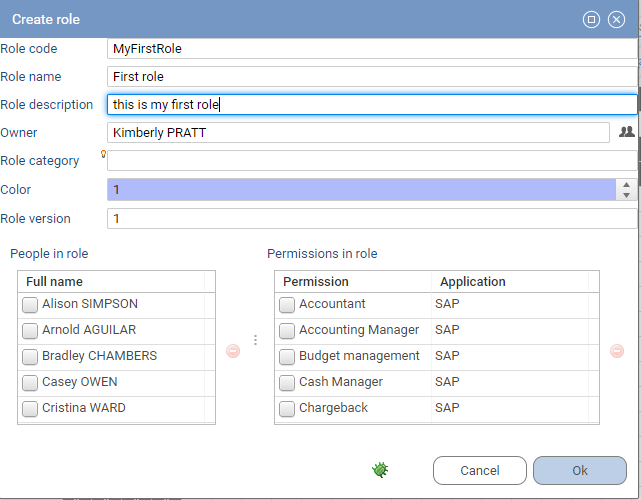

Roles are automatically assigned a color to easily identify them. You can also modify a role candidate to edit the permissions and/or identities using the tools to the right:

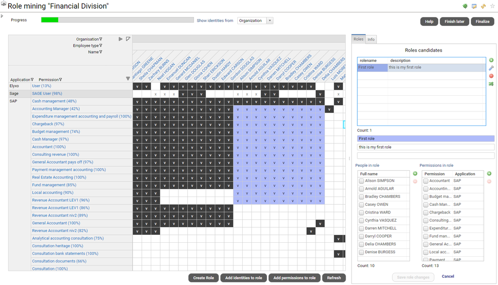

### Finish Later and Finalize

Role mining is a process that can take time depending on the organization and the scope of permissions. At any moment, you can choose to save the current status and finish later using the “Finish Later” button.

Similarly, when the role mining task is considered done, you can finalize using the “Finalize” button.

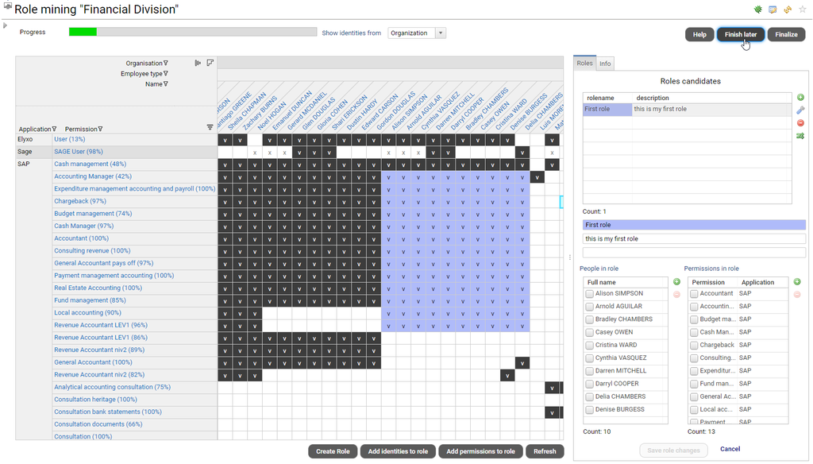

### Annotations

When you select a permission, you can use the “Permission” tab to the right of the page to see more details about the permission:

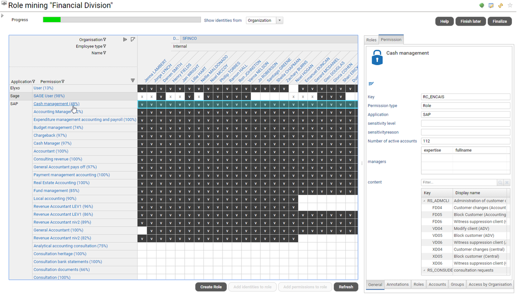

From here, you will identify a second set of tabs to the bottom of the screen, and you can use the “Annotation” tab to add an annotation to the current permission.

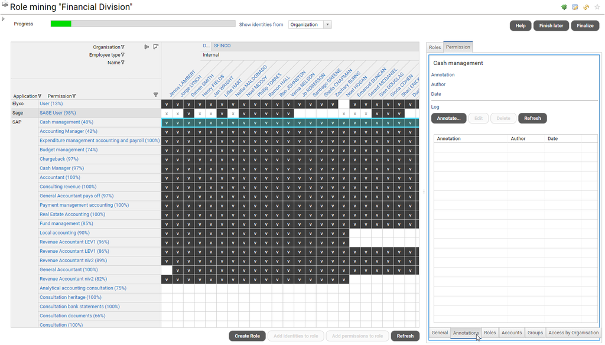

We can add and manage annotations on this permission from here.

Annotations are basically a message or a comment that can be attached to a given permission and that can be useful during the role mining process so that business people involved in the process will have a better understanding of the meaning of the permission.

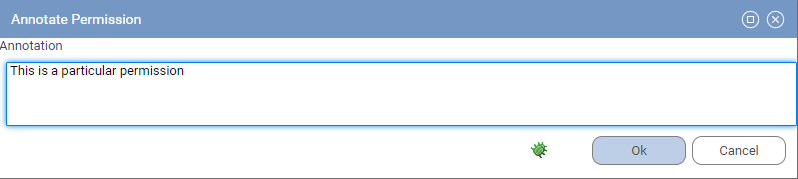

After refreshing, permissions that are annotated can be easily identified in the crosstab widget:

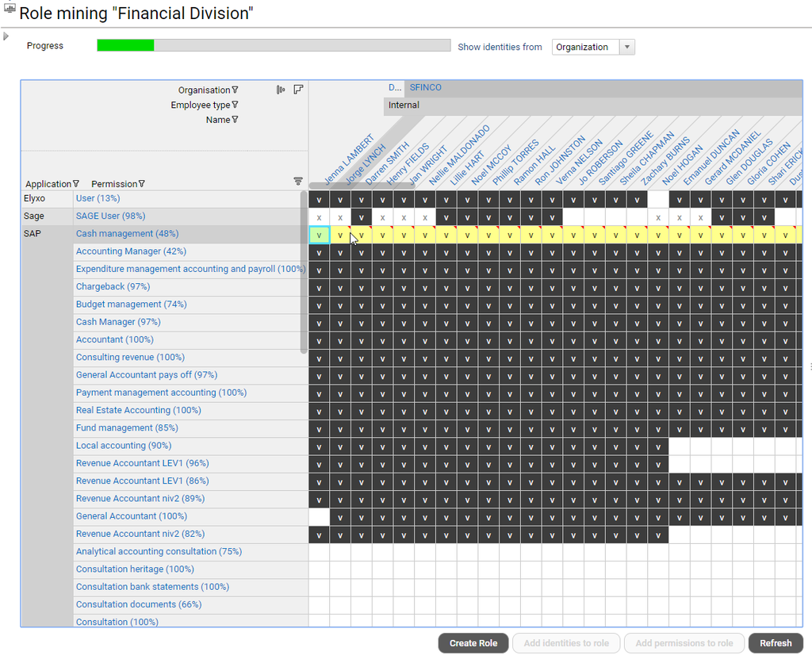

# Role Mining Administration

The role mining features provides an administration page that can be found using the “Admin” menuitem in the main portal, then “Role Mining Admin”.

## Export, Import and Delete

From this page, you will be able to see the technical details on how the information about roles is being stored in the ledger, depending on the version you have.

The role mining role schema version 1 is now deprecated (with the role mining add-on version lower than 2.3), so you will have to use version 2.

From either of the schemas, you can:

- Export

Exporting will produce an xlsx file that contains all information related to the roles and role contents as well as the permission annotations:

[figure not shown]

- Import

This is only available for the v2 of the schema, it allows to import an existing xlsx file and recreate all the roles, their contents and all the permission annotations.

- Delete roles

This is only available for v1 of the schema, it will delete the tickets in the ledger that hold information about the roles. It also deletes the permission annotations.

**Warning:** Please keep in mind that this action cannot be undone. Keep always a backup.

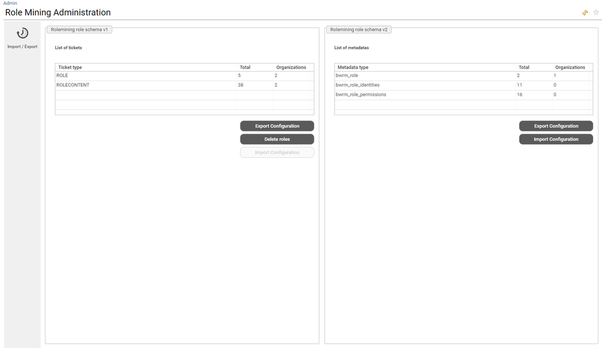

© 1995-2023 [Radiant Logic](https://developer.radiantlogic.com/)